# Risk Factor Analysis

## Outcome Variable

**Outcome Variable:** ever_sstunted

## Predictor Variables

**Intervention Variable:** mwtkg

**Adjustment Set:**

- arm
- W_mage
- meducyrs
- feducyrs
- hhwealth_quart
- W_nchldlt5
- brthmon
- W_parity
- delta_W_mage
- delta_meducyrs
- delta_feducyrs
- delta_hhwealth_quart
- delta_W_nchldlt5
- delta_brthmon
- delta_W_parity

## Stratifying Variables

The analysis was stratified on these variable(s):

- agecat
- studyid
- country

## Data Summary

| agecat | studyid | country | mwtkg | ever_sstunted | n_cell | n |
| --- | --- | --- | --- | --- | --- | --- |
| 0-24 months | ki0047075b-MAL-ED | BANGLADESH | >=58 kg | 0 | 45 | 254 |
| 0-24 months | ki0047075b-MAL-ED | BANGLADESH | >=58 kg | 1 | 3 | 254 |
| 0-24 months | ki0047075b-MAL-ED | BANGLADESH | <52 kg | 0 | 113 | 254 |
| 0-24 months | ki0047075b-MAL-ED | BANGLADESH | <52 kg | 1 | 49 | 254 |
| 0-24 months | ki0047075b-MAL-ED | BANGLADESH | [52-58) kg | 0 | 40 | 254 |
| 0-24 months | ki0047075b-MAL-ED | BANGLADESH | [52-58) kg | 1 | 4 | 254 |
| 0-24 months | ki0047075b-MAL-ED | BRAZIL | >=58 kg | 0 | 132 | 221 |
| 0-24 months | ki0047075b-MAL-ED | BRAZIL | >=58 kg | 1 | 11 | 221 |
| 0-24 months | ki0047075b-MAL-ED | BRAZIL | <52 kg | 0 | 38 | 221 |
| 0-24 months | ki0047075b-MAL-ED | BRAZIL | <52 kg | 1 | 4 | 221 |
| 0-24 months | ki0047075b-MAL-ED | BRAZIL | [52-58) kg | 0 | 30 | 221 |
| 0-24 months | ki0047075b-MAL-ED | BRAZIL | [52-58) kg | 1 | 6 | 221 |
| 0-24 months | ki0047075b-MAL-ED | INDIA | >=58 kg | 0 | 36 | 242 |
| 0-24 months | ki0047075b-MAL-ED | INDIA | >=58 kg | 1 | 6 | 242 |
| 0-24 months | ki0047075b-MAL-ED | INDIA | <52 kg | 0 | 112 | 242 |
| 0-24 months | ki0047075b-MAL-ED | INDIA | <52 kg | 1 | 38 | 242 |
| 0-24 months | ki0047075b-MAL-ED | INDIA | [52-58) kg | 0 | 36 | 242 |
| 0-24 months | ki0047075b-MAL-ED | INDIA | [52-58) kg | 1 | 14 | 242 |
| 0-24 months | ki0047075b-MAL-ED | NEPAL | >=58 kg | 0 | 75 | 238 |
| 0-24 months | ki0047075b-MAL-ED | NEPAL | >=58 kg | 1 | 5 | 238 |
| 0-24 months | ki0047075b-MAL-ED | NEPAL | <52 kg | 0 | 61 | 238 |
| 0-24 months | ki0047075b-MAL-ED | NEPAL | <52 kg | 1 | 15 | 238 |
| 0-24 months | ki0047075b-MAL-ED | NEPAL | [52-58) kg | 0 | 81 | 238 |
| 0-24 months | ki0047075b-MAL-ED | NEPAL | [52-58) kg | 1 | 1 | 238 |
| 0-24 months | ki0047075b-MAL-ED | PERU | >=58 kg | 0 | 87 | 290 |
| 0-24 months | ki0047075b-MAL-ED | PERU | >=58 kg | 1 | 17 | 290 |
| 0-24 months | ki0047075b-MAL-ED | PERU | <52 kg | 0 | 87 | 290 |
| 0-24 months | ki0047075b-MAL-ED | PERU | <52 kg | 1 | 28 | 290 |
| 0-24 months | ki0047075b-MAL-ED | PERU | [52-58) kg | 0 | 53 | 290 |
| 0-24 months | ki0047075b-MAL-ED | PERU | [52-58) kg | 1 | 18 | 290 |

[output cut: 168 more lines]

The following strata were considered:

- agecat: 0-24 months, studyid: ki0047075b-MAL-ED, country: BANGLADESH
- agecat: 0-24 months, studyid: ki0047075b-MAL-ED, country: BRAZIL
- agecat: 0-24 months, studyid: ki0047075b-MAL-ED, country: INDIA
- agecat: 0-24 months, studyid: ki0047075b-MAL-ED, country: NEPAL
- agecat: 0-24 months, studyid: ki0047075b-MAL-ED, country: PERU
- agecat: 0-24 months, studyid: ki0047075b-MAL-ED, country: SOUTH AFRICA
- agecat: 0-24 months, studyid: ki0047075b-MAL-ED, country: TANZANIA, UNITED REPUBLIC OF
- agecat: 0-24 months, studyid: ki1000304b-SAS-CompFeed, country: INDIA
- agecat: 0-24 months, studyid: ki1017093-NIH-Birth, country: BANGLADESH
- agecat: 0-24 months, studyid: ki1017093b-PROVIDE, country: BANGLADESH
- agecat: 0-24 months, studyid: ki1017093c-NIH-Crypto, country: BANGLADESH
- agecat: 0-24 months, studyid: ki1066203-TanzaniaChild2, country: TANZANIA, UNITED REPUBLIC OF
- agecat: 0-24 months, studyid: ki1112895-iLiNS-Zinc, country: BURKINA FASO
- agecat: 0-24 months, studyid: ki1119695-PROBIT, country: BELARUS
- agecat: 0-24 months, studyid: ki1126311-ZVITAMBO, country: ZIMBABWE
- agecat: 0-24 months, studyid: ki1148112-LCNI-5, country: MALAWI
- agecat: 0-24 months, studyid: kiGH5241-JiVitA-3, country: BANGLADESH
- agecat: 0-6 months, studyid: ki0047075b-MAL-ED, country: BANGLADESH
- agecat: 0-6 months, studyid: ki0047075b-MAL-ED, country: BRAZIL
- agecat: 0-6 months, studyid: ki0047075b-MAL-ED, country: INDIA
- agecat: 0-6 months, studyid: ki0047075b-MAL-ED, country: NEPAL
- agecat: 0-6 months, studyid: ki0047075b-MAL-ED, country: PERU
- agecat: 0-6 months, studyid: ki0047075b-MAL-ED, country: SOUTH AFRICA
- agecat: 0-6 months, studyid: ki0047075b-MAL-ED, country: TANZANIA, UNITED REPUBLIC OF
- agecat: 0-6 months, studyid: ki1000304b-SAS-CompFeed, country: INDIA
- agecat: 0-6 months, studyid: ki1017093-NIH-Birth, country: BANGLADESH
- agecat: 0-6 months, studyid: ki1017093b-PROVIDE, country: BANGLADESH
- agecat: 0-6 months, studyid: ki1017093c-NIH-Crypto, country: BANGLADESH
- agecat: 0-6 months, studyid: ki1066203-TanzaniaChild2, country: TANZANIA, UNITED REPUBLIC OF
- agecat: 0-6 months, studyid: ki1119695-PROBIT, country: BELARUS
- agecat: 0-6 months, studyid: ki1126311-ZVITAMBO, country: ZIMBABWE
- agecat: 0-6 months, studyid: ki1148112-LCNI-5, country: MALAWI
- agecat: 0-6 months, studyid: kiGH5241-JiVitA-3, country: BANGLADESH

### Dropped Strata

Some strata were dropped due to rare outcomes:

- agecat: 0-24 months, studyid: ki0047075b-MAL-ED, country: BANGLADESH
- agecat: 0-24 months, studyid: ki0047075b-MAL-ED, country: BRAZIL
- agecat: 0-24 months, studyid: ki0047075b-MAL-ED, country: NEPAL
- agecat: 0-6 months, studyid: ki0047075b-MAL-ED, country: BANGLADESH
- agecat: 0-6 months, studyid: ki0047075b-MAL-ED, country: BRAZIL
- agecat: 0-6 months, studyid: ki0047075b-MAL-ED, country: INDIA
- agecat: 0-6 months, studyid: ki0047075b-MAL-ED, country: NEPAL
- agecat: 0-6 months, studyid: ki0047075b-MAL-ED, country: SOUTH AFRICA
- agecat: 0-6 months, studyid: ki1017093b-PROVIDE, country: BANGLADESH
- agecat: 0-6 months, studyid: ki1148112-LCNI-5, country: MALAWI

## Methods Detail

We’re interested in the causal parameters $E[Y_a]$ for all values of $a \in \mathcal{A}$. These parameters represent the mean outcome if, possibly contrary to fact, we intervened to set all units to have $A=a$. Under the randomization and positivity assumptions, these are identified by the statistical parameters $\psi_a=E_W[E_{Y|A,W}(Y|A=a,W)]$. In addition, we’re interested in the mean of $Y$, $E[Y]$ under no intervention (the observed mean). We will estimate these parameters by using SuperLearner to fit the relevant likelihood factors – $E_{Y|A,W}(Y|A=a,W)$ and $p(A=a|W)$, and then updating our likelihood fit using a joint TMLE.

For unadjusted analyses ($W=\{\}$), initial likelihoods were estimated using Lrnr_glm to estimate the simple $E(Y|A)$ and Lrnr_mean to estimate $p(A)$. For adjusted analyses, a small library containing Lrnr_glmnet, Lrnr_xgboost, and Lrnr_mean was used.

Having estimated these parameters, we will then use the delta method to estimate relative risks and attributable risks relative to a prespecified baseline level of $A$.

# Results Detail

## Results Plots

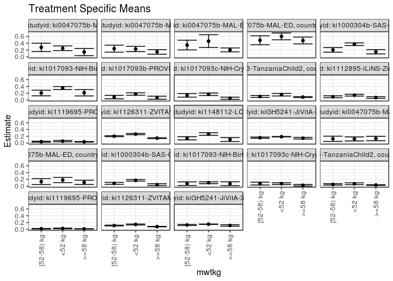

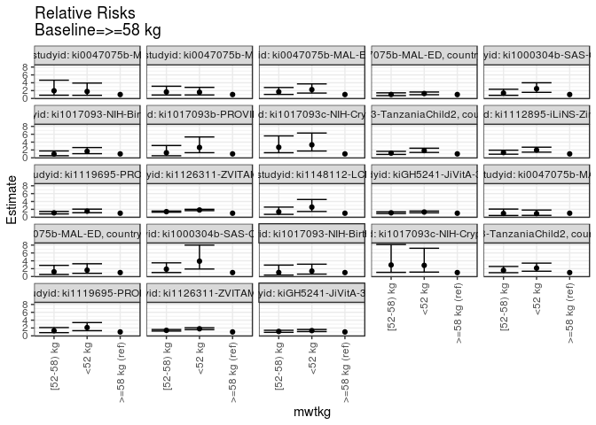

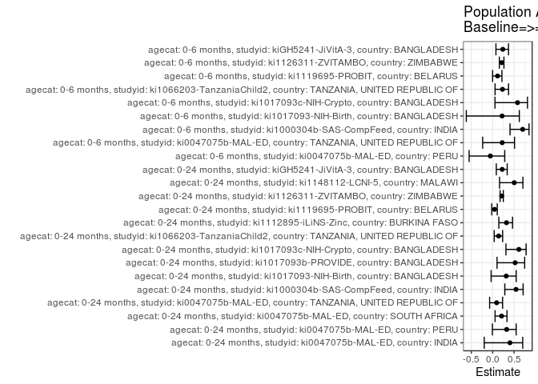

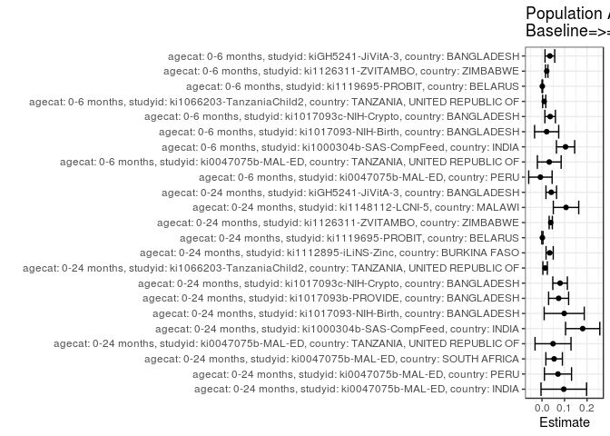

## Results Table

### Parameter: TSM

| agecat | studyid | country | intervention_level | baseline_level | estimate | ci_lower | ci_upper |
| --- | --- | --- | --- | --- | --- | --- | --- |
| 0-24 months | ki0047075b-MAL-ED | INDIA | >=58 kg | NA | 0.1428571 | 0.0368097 | 0.2489046 |
| 0-24 months | ki0047075b-MAL-ED | INDIA | <52 kg | NA | 0.2533333 | 0.1835886 | 0.3230780 |
| 0-24 months | ki0047075b-MAL-ED | INDIA | [52-58) kg | NA | 0.2800000 | 0.1552882 | 0.4047118 |
| 0-24 months | ki0047075b-MAL-ED | PERU | >=58 kg | NA | 0.1462226 | 0.0781612 | 0.2142840 |
| 0-24 months | ki0047075b-MAL-ED | PERU | <52 kg | NA | 0.2323443 | 0.1541510 | 0.3105375 |
| 0-24 months | ki0047075b-MAL-ED | PERU | [52-58) kg | NA | 0.2419842 | 0.1388944 | 0.3450739 |
| 0-24 months | ki0047075b-MAL-ED | SOUTH AFRICA | >=58 kg | NA | 0.2053649 | 0.1480775 | 0.2626523 |
| 0-24 months | ki0047075b-MAL-ED | SOUTH AFRICA | <52 kg | NA | 0.4632859 | 0.2741763 | 0.6523954 |
| 0-24 months | ki0047075b-MAL-ED | SOUTH AFRICA | [52-58) kg | NA | 0.3479498 | 0.2038976 | 0.4920020 |
| 0-24 months | ki0047075b-MAL-ED | TANZANIA, UNITED REPUBLIC OF | >=58 kg | NA | 0.4822703 | 0.3813545 | 0.5831860 |
| 0-24 months | ki0047075b-MAL-ED | TANZANIA, UNITED REPUBLIC OF | <52 kg | NA | 0.6042039 | 0.5034247 | 0.7049831 |
| 0-24 months | ki0047075b-MAL-ED | TANZANIA, UNITED REPUBLIC OF | [52-58) kg | NA | 0.4893426 | 0.3562208 | 0.6224643 |
| 0-24 months | ki1000304b-SAS-CompFeed | INDIA | >=58 kg | NA | 0.1499129 | 0.0853480 | 0.2144777 |
| 0-24 months | ki1000304b-SAS-CompFeed | INDIA | <52 kg | NA | 0.3742805 | 0.3366260 | 0.4119349 |
| 0-24 months | ki1000304b-SAS-CompFeed | INDIA | [52-58) kg | NA | 0.2054425 | 0.1379984 | 0.2728865 |
| 0-24 months | ki1017093-NIH-Birth | BANGLADESH | >=58 kg | NA | 0.2129097 | 0.1192723 | 0.3065470 |
| 0-24 months | ki1017093-NIH-Birth | BANGLADESH | <52 kg | NA | 0.3520521 | 0.3078928 | 0.3962114 |
| 0-24 months | ki1017093-NIH-Birth | BANGLADESH | [52-58) kg | NA | 0.2055413 | 0.1236257 | 0.2874569 |
| 0-24 months | ki1017093b-PROVIDE | BANGLADESH | >=58 kg | NA | 0.0666667 | 0.0220029 | 0.1113304 |
| 0-24 months | ki1017093b-PROVIDE | BANGLADESH | <52 kg | NA | 0.1759259 | 0.1399941 | 0.2118577 |
| 0-24 months | ki1017093b-PROVIDE | BANGLADESH | [52-58) kg | NA | 0.0854701 | 0.0347726 | 0.1361675 |
| 0-24 months | ki1017093c-NIH-Crypto | BANGLADESH | >=58 kg | NA | 0.0507770 | 0.0197229 | 0.0818310 |
| 0-24 months | ki1017093c-NIH-Crypto | BANGLADESH | <52 kg | NA | 0.1677420 | 0.1312037 | 0.2042802 |
| 0-24 months | ki1017093c-NIH-Crypto | BANGLADESH | [52-58) kg | NA | 0.1367022 | 0.0823505 | 0.1910539 |
| 0-24 months | ki1066203-TanzaniaChild2 | TANZANIA, UNITED REPUBLIC OF | >=58 kg | NA | 0.0852417 | 0.0708859 | 0.0995974 |
| 0-24 months | ki1066203-TanzaniaChild2 | TANZANIA, UNITED REPUBLIC OF | <52 kg | NA | 0.1555367 | 0.1185536 | 0.1925198 |
| 0-24 months | ki1066203-TanzaniaChild2 | TANZANIA, UNITED REPUBLIC OF | [52-58) kg | NA | 0.1014439 | 0.0735737 | 0.1293142 |
| 0-24 months | ki1112895-iLiNS-Zinc | BURKINA FASO | >=58 kg | NA | 0.0711248 | 0.0468061 | 0.0954434 |
| 0-24 months | ki1112895-iLiNS-Zinc | BURKINA FASO | <52 kg | NA | 0.1405564 | 0.1150385 | 0.1660742 |
| 0-24 months | ki1112895-iLiNS-Zinc | BURKINA FASO | [52-58) kg | NA | 0.0948085 | 0.0660918 | 0.1235251 |
| 0-24 months | ki1119695-PROBIT | BELARUS | >=58 kg | NA | 0.0371140 | 0.0287744 | 0.0454537 |
| 0-24 months | ki1119695-PROBIT | BELARUS | <52 kg | NA | 0.0562268 | 0.0370244 | 0.0754291 |
| 0-24 months | ki1119695-PROBIT | BELARUS | [52-58) kg | NA | 0.0407263 | 0.0271225 | 0.0543302 |
| 0-24 months | ki1126311-ZVITAMBO | ZIMBABWE | >=58 kg | NA | 0.1447668 | 0.1356435 | 0.1538902 |
| 0-24 months | ki1126311-ZVITAMBO | ZIMBABWE | <52 kg | NA | 0.2646025 | 0.2464447 | 0.2827602 |
| 0-24 months | ki1126311-ZVITAMBO | ZIMBABWE | [52-58) kg | NA | 0.2030920 | 0.1881511 | 0.2180330 |
| 0-24 months | ki1148112-LCNI-5 | MALAWI | >=58 kg | NA | 0.1045160 | 0.0470739 | 0.1619580 |
| 0-24 months | ki1148112-LCNI-5 | MALAWI | <52 kg | NA | 0.2667379 | 0.2281268 | 0.3053491 |
| 0-24 months | ki1148112-LCNI-5 | MALAWI | [52-58) kg | NA | 0.1408178 | 0.0941797 | 0.1874558 |
| 0-24 months | kiGH5241-JiVitA-3 | BANGLADESH | >=58 kg | NA | 0.1434150 | 0.1194754 | 0.1673545 |
| 0-24 months | kiGH5241-JiVitA-3 | BANGLADESH | <52 kg | NA | 0.1873508 | 0.1815219 | 0.1931797 |
| 0-24 months | kiGH5241-JiVitA-3 | BANGLADESH | [52-58) kg | NA | 0.1584315 | 0.1401391 | 0.1767238 |
| 0-6 months | ki0047075b-MAL-ED | PERU | >=58 kg | NA | 0.1346154 | 0.0689051 | 0.2003257 |
| 0-6 months | ki0047075b-MAL-ED | PERU | <52 kg | NA | 0.1217391 | 0.0618737 | 0.1816046 |
| 0-6 months | ki0047075b-MAL-ED | PERU | [52-58) kg | NA | 0.1267606 | 0.0492381 | 0.2042831 |
| 0-6 months | ki0047075b-MAL-ED | TANZANIA, UNITED REPUBLIC OF | >=58 kg | NA | 0.1122449 | 0.0496246 | 0.1748652 |
| 0-6 months | ki0047075b-MAL-ED | TANZANIA, UNITED REPUBLIC OF | <52 kg | NA | 0.1818182 | 0.1056938 | 0.2579426 |
| 0-6 months | ki0047075b-MAL-ED | TANZANIA, UNITED REPUBLIC OF | [52-58) kg | NA | 0.1355932 | 0.0480646 | 0.2231218 |
| 0-6 months | ki1000304b-SAS-CompFeed | INDIA | >=58 kg | NA | 0.0442478 | 0.0170549 | 0.0714407 |
| 0-6 months | ki1000304b-SAS-CompFeed | INDIA | <52 kg | NA | 0.1727116 | 0.1479652 | 0.1974580 |
| 0-6 months | ki1000304b-SAS-CompFeed | INDIA | [52-58) kg | NA | 0.0829876 | 0.0537728 | 0.1122023 |
| 0-6 months | ki1017093-NIH-Birth | BANGLADESH | >=58 kg | NA | 0.0731707 | 0.0167608 | 0.1295806 |
| 0-6 months | ki1017093-NIH-Birth | BANGLADESH | <52 kg | NA | 0.1015453 | 0.0737083 | 0.1293823 |
| 0-6 months | ki1017093-NIH-Birth | BANGLADESH | [52-58) kg | NA | 0.0744681 | 0.0213539 | 0.1275823 |
| 0-6 months | ki1017093c-NIH-Crypto | BANGLADESH | >=58 kg | NA | 0.0260417 | 0.0034998 | 0.0485835 |
| 0-6 months | ki1017093c-NIH-Crypto | BANGLADESH | <52 kg | NA | 0.0738916 | 0.0484291 | 0.0993541 |
| 0-6 months | ki1017093c-NIH-Crypto | BANGLADESH | [52-58) kg | NA | 0.0764331 | 0.0348458 | 0.1180205 |
| 0-6 months | ki1066203-TanzaniaChild2 | TANZANIA, UNITED REPUBLIC OF | >=58 kg | NA | 0.0330937 | 0.0238219 | 0.0423655 |
| 0-6 months | ki1066203-TanzaniaChild2 | TANZANIA, UNITED REPUBLIC OF | <52 kg | NA | 0.0709254 | 0.0446040 | 0.0972467 |
| 0-6 months | ki1066203-TanzaniaChild2 | TANZANIA, UNITED REPUBLIC OF | [52-58) kg | NA | 0.0522177 | 0.0317628 | 0.0726726 |
| 0-6 months | ki1119695-PROBIT | BELARUS | >=58 kg | NA | 0.0115177 | 0.0080401 | 0.0149954 |
| 0-6 months | ki1119695-PROBIT | BELARUS | <52 kg | NA | 0.0243630 | 0.0136172 | 0.0351088 |
| 0-6 months | ki1119695-PROBIT | BELARUS | [52-58) kg | NA | 0.0151159 | 0.0070003 | 0.0232315 |
| 0-6 months | ki1126311-ZVITAMBO | ZIMBABWE | >=58 kg | NA | 0.0782104 | 0.0712526 | 0.0851682 |
| 0-6 months | ki1126311-ZVITAMBO | ZIMBABWE | <52 kg | NA | 0.1410613 | 0.1266850 | 0.1554376 |
| 0-6 months | ki1126311-ZVITAMBO | ZIMBABWE | [52-58) kg | NA | 0.1097528 | 0.0979945 | 0.1215110 |
| 0-6 months | kiGH5241-JiVitA-3 | BANGLADESH | >=58 kg | NA | 0.1124059 | 0.0903377 | 0.1344741 |
| 0-6 months | kiGH5241-JiVitA-3 | BANGLADESH | <52 kg | NA | 0.1497220 | 0.1444886 | 0.1549553 |
| 0-6 months | kiGH5241-JiVitA-3 | BANGLADESH | [52-58) kg | NA | 0.1266738 | 0.1101194 | 0.1432282 |

### Parameter: E(Y)

| agecat | studyid | country | intervention_level | baseline_level | estimate | ci_lower | ci_upper |
| --- | --- | --- | --- | --- | --- | --- | --- |
| 0-24 months | ki0047075b-MAL-ED | INDIA | NA | NA | 0.2396694 | 0.1857746 | 0.2935643 |
| 0-24 months | ki0047075b-MAL-ED | PERU | NA | NA | 0.2172414 | 0.1696986 | 0.2647841 |
| 0-24 months | ki0047075b-MAL-ED | SOUTH AFRICA | NA | NA | 0.2592593 | 0.2068905 | 0.3116280 |
| 0-24 months | ki0047075b-MAL-ED | TANZANIA, UNITED REPUBLIC OF | NA | NA | 0.5312500 | 0.4700011 | 0.5924989 |
| 0-24 months | ki1000304b-SAS-CompFeed | INDIA | NA | NA | 0.3306931 | 0.3017014 | 0.3596847 |
| 0-24 months | ki1017093-NIH-Birth | BANGLADESH | NA | NA | 0.3116057 | 0.2753823 | 0.3478292 |
| 0-24 months | ki1017093b-PROVIDE | BANGLADESH | NA | NA | 0.1405082 | 0.1141551 | 0.1668613 |
| 0-24 months | ki1017093c-NIH-Crypto | BANGLADESH | NA | NA | 0.1311258 | 0.1070332 | 0.1552185 |
| 0-24 months | ki1066203-TanzaniaChild2 | TANZANIA, UNITED REPUBLIC OF | NA | NA | 0.0990646 | 0.0869885 | 0.1111408 |
| 0-24 months | ki1112895-iLiNS-Zinc | BURKINA FASO | NA | NA | 0.1050995 | 0.0855497 | 0.1246493 |
| 0-24 months | ki1119695-PROBIT | BELARUS | NA | NA | 0.0388469 | 0.0306142 | 0.0470797 |
| 0-24 months | ki1126311-ZVITAMBO | ZIMBABWE | NA | NA | 0.1835951 | 0.1764261 | 0.1907642 |
| 0-24 months | ki1148112-LCNI-5 | MALAWI | NA | NA | 0.2112172 | 0.1835650 | 0.2388693 |
| 0-24 months | kiGH5241-JiVitA-3 | BANGLADESH | NA | NA | 0.1844757 | 0.1788759 | 0.1900754 |
| 0-6 months | ki0047075b-MAL-ED | PERU | NA | NA | 0.1275862 | 0.0891215 | 0.1660509 |
| 0-6 months | ki0047075b-MAL-ED | TANZANIA, UNITED REPUBLIC OF | NA | NA | 0.1445313 | 0.1013733 | 0.1876892 |
| 0-6 months | ki1000304b-SAS-CompFeed | INDIA | NA | NA | 0.1488095 | 0.1307571 | 0.1668620 |
| 0-6 months | ki1017093-NIH-Birth | BANGLADESH | NA | NA | 0.0937997 | 0.0709973 | 0.1166021 |
| 0-6 months | ki1017093c-NIH-Crypto | BANGLADESH | NA | NA | 0.0622517 | 0.0450059 | 0.0794974 |
| 0-6 months | ki1066203-TanzaniaChild2 | TANZANIA, UNITED REPUBLIC OF | NA | NA | 0.0429422 | 0.0347475 | 0.0511369 |
| 0-6 months | ki1119695-PROBIT | BELARUS | NA | NA | 0.0129974 | 0.0096142 | 0.0163806 |
| 0-6 months | ki1126311-ZVITAMBO | ZIMBABWE | NA | NA | 0.0991957 | 0.0936569 | 0.1047345 |
| 0-6 months | kiGH5241-JiVitA-3 | BANGLADESH | NA | NA | 0.1473645 | 0.1423155 | 0.1524136 |

### Parameter: RR

| agecat | studyid | country | intervention_level | baseline_level | estimate | ci_lower | ci_upper |
| --- | --- | --- | --- | --- | --- | --- | --- |
| 0-24 months | ki0047075b-MAL-ED | INDIA | >=58 kg | >=58 kg | 1.0000000 | 1.0000000 | 1.000000 |
| 0-24 months | ki0047075b-MAL-ED | INDIA | <52 kg | >=58 kg | 1.7733333 | 0.8034193 | 3.914159 |
| 0-24 months | ki0047075b-MAL-ED | INDIA | [52-58) kg | >=58 kg | 1.9600000 | 0.8246831 | 4.658274 |
| 0-24 months | ki0047075b-MAL-ED | PERU | >=58 kg | >=58 kg | 1.0000000 | 1.0000000 | 1.000000 |
| 0-24 months | ki0047075b-MAL-ED | PERU | <52 kg | >=58 kg | 1.5889764 | 0.8938632 | 2.824645 |
| 0-24 months | ki0047075b-MAL-ED | PERU | [52-58) kg | >=58 kg | 1.6549029 | 0.8802117 | 3.111415 |
| 0-24 months | ki0047075b-MAL-ED | SOUTH AFRICA | >=58 kg | >=58 kg | 1.0000000 | 1.0000000 | 1.000000 |
| 0-24 months | ki0047075b-MAL-ED | SOUTH AFRICA | <52 kg | >=58 kg | 2.2559158 | 1.3738848 | 3.704209 |
| 0-24 months | ki0047075b-MAL-ED | SOUTH AFRICA | [52-58) kg | >=58 kg | 1.6943004 | 1.0281249 | 2.792126 |
| 0-24 months | ki0047075b-MAL-ED | TANZANIA, UNITED REPUBLIC OF | >=58 kg | >=58 kg | 1.0000000 | 1.0000000 | 1.000000 |
| 0-24 months | ki0047075b-MAL-ED | TANZANIA, UNITED REPUBLIC OF | <52 kg | >=58 kg | 1.2528326 | 0.9580387 | 1.638336 |
| 0-24 months | ki0047075b-MAL-ED | TANZANIA, UNITED REPUBLIC OF | [52-58) kg | >=58 kg | 1.0146647 | 0.7201987 | 1.429528 |
| 0-24 months | ki1000304b-SAS-CompFeed | INDIA | >=58 kg | >=58 kg | 1.0000000 | 1.0000000 | 1.000000 |
| 0-24 months | ki1000304b-SAS-CompFeed | INDIA | <52 kg | >=58 kg | 2.4966535 | 1.5580118 | 4.000790 |
| 0-24 months | ki1000304b-SAS-CompFeed | INDIA | [52-58) kg | >=58 kg | 1.3704126 | 0.7967267 | 2.357183 |
| 0-24 months | ki1017093-NIH-Birth | BANGLADESH | >=58 kg | >=58 kg | 1.0000000 | 1.0000000 | 1.000000 |
| 0-24 months | ki1017093-NIH-Birth | BANGLADESH | <52 kg | >=58 kg | 1.6535282 | 1.0464839 | 2.612707 |
| 0-24 months | ki1017093-NIH-Birth | BANGLADESH | [52-58) kg | >=58 kg | 0.9653923 | 0.5332505 | 1.747738 |
| 0-24 months | ki1017093b-PROVIDE | BANGLADESH | >=58 kg | >=58 kg | 1.0000000 | 1.0000000 | 1.000000 |
| 0-24 months | ki1017093b-PROVIDE | BANGLADESH | <52 kg | >=58 kg | 2.6388889 | 1.3099126 | 5.316183 |
| 0-24 months | ki1017093b-PROVIDE | BANGLADESH | [52-58) kg | >=58 kg | 1.2820513 | 0.5239569 | 3.137005 |
| 0-24 months | ki1017093c-NIH-Crypto | BANGLADESH | >=58 kg | >=58 kg | 1.0000000 | 1.0000000 | 1.000000 |
| 0-24 months | ki1017093c-NIH-Crypto | BANGLADESH | <52 kg | >=58 kg | 3.3035056 | 1.7267743 | 6.319963 |
| 0-24 months | ki1017093c-NIH-Crypto | BANGLADESH | [52-58) kg | >=58 kg | 2.6922098 | 1.2979664 | 5.584115 |
| 0-24 months | ki1066203-TanzaniaChild2 | TANZANIA, UNITED REPUBLIC OF | >=58 kg | >=58 kg | 1.0000000 | 1.0000000 | 1.000000 |
| 0-24 months | ki1066203-TanzaniaChild2 | TANZANIA, UNITED REPUBLIC OF | <52 kg | >=58 kg | 1.8246549 | 1.3631690 | 2.442372 |
| 0-24 months | ki1066203-TanzaniaChild2 | TANZANIA, UNITED REPUBLIC OF | [52-58) kg | >=58 kg | 1.1900739 | 0.8622140 | 1.642604 |
| 0-24 months | ki1112895-iLiNS-Zinc | BURKINA FASO | >=58 kg | >=58 kg | 1.0000000 | 1.0000000 | 1.000000 |
| 0-24 months | ki1112895-iLiNS-Zinc | BURKINA FASO | <52 kg | >=58 kg | 1.9761938 | 1.4427908 | 2.706797 |
| 0-24 months | ki1112895-iLiNS-Zinc | BURKINA FASO | [52-58) kg | >=58 kg | 1.3329877 | 0.9158346 | 1.940150 |
| 0-24 months | ki1119695-PROBIT | BELARUS | >=58 kg | >=58 kg | 1.0000000 | 1.0000000 | 1.000000 |
| 0-24 months | ki1119695-PROBIT | BELARUS | <52 kg | >=58 kg | 1.5149726 | 1.1237716 | 2.042356 |
| 0-24 months | ki1119695-PROBIT | BELARUS | [52-58) kg | >=58 kg | 1.0973296 | 0.8259983 | 1.457790 |
| 0-24 months | ki1126311-ZVITAMBO | ZIMBABWE | >=58 kg | >=58 kg | 1.0000000 | 1.0000000 | 1.000000 |
| 0-24 months | ki1126311-ZVITAMBO | ZIMBABWE | <52 kg | >=58 kg | 1.8277837 | 1.6651475 | 2.006305 |
| 0-24 months | ki1126311-ZVITAMBO | ZIMBABWE | [52-58) kg | >=58 kg | 1.4028906 | 1.2734206 | 1.545524 |
| 0-24 months | ki1148112-LCNI-5 | MALAWI | >=58 kg | >=58 kg | 1.0000000 | 1.0000000 | 1.000000 |
| 0-24 months | ki1148112-LCNI-5 | MALAWI | <52 kg | >=58 kg | 2.5521261 | 1.4455876 | 4.505675 |
| 0-24 months | ki1148112-LCNI-5 | MALAWI | [52-58) kg | >=58 kg | 1.3473324 | 0.7089257 | 2.560641 |
| 0-24 months | kiGH5241-JiVitA-3 | BANGLADESH | >=58 kg | >=58 kg | 1.0000000 | 1.0000000 | 1.000000 |
| 0-24 months | kiGH5241-JiVitA-3 | BANGLADESH | <52 kg | >=58 kg | 1.3063546 | 1.1050899 | 1.544274 |
| 0-24 months | kiGH5241-JiVitA-3 | BANGLADESH | [52-58) kg | >=58 kg | 1.1047067 | 0.9026153 | 1.352046 |
| 0-6 months | ki0047075b-MAL-ED | PERU | >=58 kg | >=58 kg | 1.0000000 | 1.0000000 | 1.000000 |
| 0-6 months | ki0047075b-MAL-ED | PERU | <52 kg | >=58 kg | 0.9043478 | 0.4522910 | 1.808228 |
| 0-6 months | ki0047075b-MAL-ED | PERU | [52-58) kg | >=58 kg | 0.9416499 | 0.4305852 | 2.059301 |
| 0-6 months | ki0047075b-MAL-ED | TANZANIA, UNITED REPUBLIC OF | >=58 kg | >=58 kg | 1.0000000 | 1.0000000 | 1.000000 |
| 0-6 months | ki0047075b-MAL-ED | TANZANIA, UNITED REPUBLIC OF | <52 kg | >=58 kg | 1.6198347 | 0.8063817 | 3.253874 |
| 0-6 months | ki0047075b-MAL-ED | TANZANIA, UNITED REPUBLIC OF | [52-58) kg | >=58 kg | 1.2080123 | 0.5146756 | 2.835366 |
| 0-6 months | ki1000304b-SAS-CompFeed | INDIA | >=58 kg | >=58 kg | 1.0000000 | 1.0000000 | 1.000000 |
| 0-6 months | ki1000304b-SAS-CompFeed | INDIA | <52 kg | >=58 kg | 3.9032814 | 1.9049723 | 7.997809 |
| 0-6 months | ki1000304b-SAS-CompFeed | INDIA | [52-58) kg | >=58 kg | 1.8755186 | 1.0096478 | 3.483958 |
| 0-6 months | ki1017093-NIH-Birth | BANGLADESH | >=58 kg | >=58 kg | 1.0000000 | 1.0000000 | 1.000000 |
| 0-6 months | ki1017093-NIH-Birth | BANGLADESH | <52 kg | >=58 kg | 1.3877851 | 0.6123111 | 3.145374 |
| 0-6 months | ki1017093-NIH-Birth | BANGLADESH | [52-58) kg | >=58 kg | 1.0177305 | 0.3560469 | 2.909098 |
| 0-6 months | ki1017093c-NIH-Crypto | BANGLADESH | >=58 kg | >=58 kg | 1.0000000 | 1.0000000 | 1.000000 |
| 0-6 months | ki1017093c-NIH-Crypto | BANGLADESH | <52 kg | >=58 kg | 2.8374384 | 1.1176468 | 7.203579 |
| 0-6 months | ki1017093c-NIH-Crypto | BANGLADESH | [52-58) kg | >=58 kg | 2.9350318 | 1.0558100 | 8.159055 |
| 0-6 months | ki1066203-TanzaniaChild2 | TANZANIA, UNITED REPUBLIC OF | >=58 kg | >=58 kg | 1.0000000 | 1.0000000 | 1.000000 |
| 0-6 months | ki1066203-TanzaniaChild2 | TANZANIA, UNITED REPUBLIC OF | <52 kg | >=58 kg | 2.1431693 | 1.3458770 | 3.412775 |
| 0-6 months | ki1066203-TanzaniaChild2 | TANZANIA, UNITED REPUBLIC OF | [52-58) kg | >=58 kg | 1.5778744 | 0.9746682 | 2.554395 |
| 0-6 months | ki1119695-PROBIT | BELARUS | >=58 kg | >=58 kg | 1.0000000 | 1.0000000 | 1.000000 |
| 0-6 months | ki1119695-PROBIT | BELARUS | <52 kg | >=58 kg | 2.1152600 | 1.3216959 | 3.385291 |
| 0-6 months | ki1119695-PROBIT | BELARUS | [52-58) kg | >=58 kg | 1.3124013 | 0.8162864 | 2.110040 |
| 0-6 months | ki1126311-ZVITAMBO | ZIMBABWE | >=58 kg | >=58 kg | 1.0000000 | 1.0000000 | 1.000000 |
| 0-6 months | ki1126311-ZVITAMBO | ZIMBABWE | <52 kg | >=58 kg | 1.8036131 | 1.5753518 | 2.064948 |
| 0-6 months | ki1126311-ZVITAMBO | ZIMBABWE | [52-58) kg | >=58 kg | 1.4033015 | 1.2208747 | 1.612987 |
| 0-6 months | kiGH5241-JiVitA-3 | BANGLADESH | >=58 kg | >=58 kg | 1.0000000 | 1.0000000 | 1.000000 |
| 0-6 months | kiGH5241-JiVitA-3 | BANGLADESH | <52 kg | >=58 kg | 1.3319761 | 1.0945943 | 1.620838 |
| 0-6 months | kiGH5241-JiVitA-3 | BANGLADESH | [52-58) kg | >=58 kg | 1.1269318 | 0.8936373 | 1.421131 |

### Parameter: PAR

| agecat | studyid | country | intervention_level | baseline_level | estimate | ci_lower | ci_upper |
| --- | --- | --- | --- | --- | --- | --- | --- |
| 0-24 months | ki0047075b-MAL-ED | INDIA | >=58 kg | NA | 0.0968123 | -0.0044158 | 0.1980403 |
| 0-24 months | ki0047075b-MAL-ED | PERU | >=58 kg | NA | 0.0710188 | 0.0108135 | 0.1312241 |
| 0-24 months | ki0047075b-MAL-ED | SOUTH AFRICA | >=58 kg | NA | 0.0538944 | 0.0172264 | 0.0905624 |
| 0-24 months | ki0047075b-MAL-ED | TANZANIA, UNITED REPUBLIC OF | >=58 kg | NA | 0.0489797 | -0.0309098 | 0.1288693 |
| 0-24 months | ki1000304b-SAS-CompFeed | INDIA | >=58 kg | NA | 0.1807802 | 0.1048009 | 0.2567595 |
| 0-24 months | ki1017093-NIH-Birth | BANGLADESH | >=58 kg | NA | 0.0986961 | 0.0097508 | 0.1876414 |
| 0-24 months | ki1017093b-PROVIDE | BANGLADESH | >=58 kg | NA | 0.0738416 | 0.0294153 | 0.1182678 |
| 0-24 months | ki1017093c-NIH-Crypto | BANGLADESH | >=58 kg | NA | 0.0803489 | 0.0479699 | 0.1127279 |
| 0-24 months | ki1066203-TanzaniaChild2 | TANZANIA, UNITED REPUBLIC OF | >=58 kg | NA | 0.0138229 | 0.0039561 | 0.0236898 |
| 0-24 months | ki1112895-iLiNS-Zinc | BURKINA FASO | >=58 kg | NA | 0.0339747 | 0.0180219 | 0.0499275 |
| 0-24 months | ki1119695-PROBIT | BELARUS | >=58 kg | NA | 0.0017329 | -0.0007984 | 0.0042642 |
| 0-24 months | ki1126311-ZVITAMBO | ZIMBABWE | >=58 kg | NA | 0.0388283 | 0.0317744 | 0.0458823 |
| 0-24 months | ki1148112-LCNI-5 | MALAWI | >=58 kg | NA | 0.1067012 | 0.0502832 | 0.1631192 |
| 0-24 months | kiGH5241-JiVitA-3 | BANGLADESH | >=58 kg | NA | 0.0410607 | 0.0175728 | 0.0645486 |
| 0-6 months | ki0047075b-MAL-ED | PERU | >=58 kg | NA | -0.0070292 | -0.0589949 | 0.0449366 |
| 0-6 months | ki0047075b-MAL-ED | TANZANIA, UNITED REPUBLIC OF | >=58 kg | NA | 0.0322864 | -0.0204551 | 0.0850278 |
| 0-6 months | ki1000304b-SAS-CompFeed | INDIA | >=58 kg | NA | 0.1045617 | 0.0641514 | 0.1449721 |
| 0-6 months | ki1017093-NIH-Birth | BANGLADESH | >=58 kg | NA | 0.0206290 | -0.0329654 | 0.0742233 |
| 0-6 months | ki1017093c-NIH-Crypto | BANGLADESH | >=58 kg | NA | 0.0362100 | 0.0128197 | 0.0596003 |
| 0-6 months | ki1066203-TanzaniaChild2 | TANZANIA, UNITED REPUBLIC OF | >=58 kg | NA | 0.0098485 | 0.0028823 | 0.0168147 |
| 0-6 months | ki1119695-PROBIT | BELARUS | >=58 kg | NA | 0.0014797 | 0.0000635 | 0.0028959 |
| 0-6 months | ki1126311-ZVITAMBO | ZIMBABWE | >=58 kg | NA | 0.0209853 | 0.0155411 | 0.0264295 |
| 0-6 months | kiGH5241-JiVitA-3 | BANGLADESH | >=58 kg | NA | 0.0349586 | 0.0133923 | 0.0565250 |

### Parameter: PAF

| agecat | studyid | country | intervention_level | baseline_level | estimate | ci_lower | ci_upper |
| --- | --- | --- | --- | --- | --- | --- | --- |
| 0-24 months | ki0047075b-MAL-ED | INDIA | >=58 kg | NA | 0.4039409 | -0.1982678 | 0.7034999 |
| 0-24 months | ki0047075b-MAL-ED | PERU | >=58 kg | NA | 0.3269119 | -0.0062261 | 0.5497556 |
| 0-24 months | ki0047075b-MAL-ED | SOUTH AFRICA | >=58 kg | NA | 0.2078784 | 0.0561278 | 0.3352313 |
| 0-24 months | ki0047075b-MAL-ED | TANZANIA, UNITED REPUBLIC OF | >=58 kg | NA | 0.0921972 | -0.0718630 | 0.2311462 |
| 0-24 months | ki1000304b-SAS-CompFeed | INDIA | >=58 kg | NA | 0.5466707 | 0.2842558 | 0.7128758 |
| 0-24 months | ki1017093-NIH-Birth | BANGLADESH | >=58 kg | NA | 0.3167338 | -0.0372330 | 0.5499057 |
| 0-24 months | ki1017093b-PROVIDE | BANGLADESH | >=58 kg | NA | 0.5255319 | 0.1015731 | 0.7494287 |
| 0-24 months | ki1017093c-NIH-Crypto | BANGLADESH | >=58 kg | NA | 0.6127616 | 0.3102695 | 0.7825910 |
| 0-24 months | ki1066203-TanzaniaChild2 | TANZANIA, UNITED REPUBLIC OF | >=58 kg | NA | 0.1395345 | 0.0352907 | 0.2325141 |
| 0-24 months | ki1112895-iLiNS-Zinc | BURKINA FASO | >=58 kg | NA | 0.3232623 | 0.1438367 | 0.4650858 |
| 0-24 months | ki1119695-PROBIT | BELARUS | >=58 kg | NA | 0.0446081 | -0.0224329 | 0.1072532 |
| 0-24 months | ki1126311-ZVITAMBO | ZIMBABWE | >=58 kg | NA | 0.2114888 | 0.1727247 | 0.2484364 |
| 0-24 months | ki1148112-LCNI-5 | MALAWI | >=58 kg | NA | 0.5051730 | 0.1606070 | 0.7082966 |
| 0-24 months | kiGH5241-JiVitA-3 | BANGLADESH | >=58 kg | NA | 0.2225805 | 0.0843281 | 0.3399588 |
| 0-6 months | ki0047075b-MAL-ED | PERU | >=58 kg | NA | -0.0550936 | -0.5518361 | 0.2826418 |
| 0-6 months | ki0047075b-MAL-ED | TANZANIA, UNITED REPUBLIC OF | >=58 kg | NA | 0.2233867 | -0.2352083 | 0.5117193 |
| 0-6 months | ki1000304b-SAS-CompFeed | INDIA | >=58 kg | NA | 0.7026549 | 0.4061002 | 0.8511295 |
| 0-6 months | ki1017093-NIH-Birth | BANGLADESH | >=58 kg | NA | 0.2199256 | -0.6183339 | 0.6239861 |
| 0-6 months | ki1017093c-NIH-Crypto | BANGLADESH | >=58 kg | NA | 0.5816711 | 0.0535431 | 0.8151009 |
| 0-6 months | ki1066203-TanzaniaChild2 | TANZANIA, UNITED REPUBLIC OF | >=58 kg | NA | 0.2293429 | 0.0556482 | 0.3710899 |
| 0-6 months | ki1119695-PROBIT | BELARUS | >=58 kg | NA | 0.1138431 | -0.0019085 | 0.2162218 |
| 0-6 months | ki1126311-ZVITAMBO | ZIMBABWE | >=58 kg | NA | 0.2115547 | 0.1558638 | 0.2635715 |
| 0-6 months | kiGH5241-JiVitA-3 | BANGLADESH | >=58 kg | NA | 0.2372256 | 0.0757858 | 0.3704655 |